# Heart Disease Prediction

Haya Abdeh

9th July 2021

Abstract

This is the second project for the Harvard Data Science Professional Program by Prof. of Biostatistics Rafael Irizarry from Harvard University. In this capstone project, we will choose our own data to make analysis and apply machine learning methods.

## Summary

As we will choose our own Data set to analyze, we will make a study about the Heart Disease Data set, we will analyze it, visualize it, and apply machine learning methods to make prediction if an individual will have a heart disease or not.  
The data set has been updated about four months ago, and published on kaggle site. the data set can be downloaded from this link https://www.kaggle.com/rashikrahmanpritom/heart-attack-analysis-prediction-dataset  
or from this site  
https://archive.ics.uci.edu/ml/datasets/heart+disease  
we will work with (heart.csv) file, we will explore the date set and all its variables and analyze the relationship between them and apply machine learning methods to make our predictions.

## Introduction

Data science is the gate to introduce machine learning as a technique to describe big data and extract knowledge by applying algorithms that analyze and process data into helpful information and naturally intuitive solutions.  
Machine learning methods have become useful in the development of medicine in terms of improving methods for diagnosing diseases and predicting their occurrence by knowing some important data about individuals.  
In this study, we will explore the Heart Data set and we are going to predict if an individual will develop heart disease or not by applying machine learning algorithms to make our predictions and to compare between each results to find the appropriate technique which make our prediction more accurate.  
We will compute the accuracy of our prediction using these machine learning methods:  
Logistic Regression  
Regression and Decision Trees  
Quadrant Discriminant Analysis (QDA)  
Linear Discriminamt Analaysis (LDA)  
K-Nearest Neighbours Classifier (KNN)  
Support Vector Machine (SVM)  
Random Forest (RF)  
Gradient Boosting Machine (GBM)

Executive Summary  
We start with loading all needed packages and loading the Heart data set (heart.csv) from this link:  
https://www.kaggle.com/rashikrahmanpritom/heart-attack-analysis-prediction-dataset  
Then we will start to explore our data set and analyze it.  
Let us start

```r
# Loading all needed libraries

library(dplyr)
library(tidyverse)
library(kableExtra)
library(tidyr)
library(ggplot2)
library(plotly)
library(gbm)
library(caret)
library(xgboost)
library(e1071)
library(class)
library(lightgbm)
library(ROCR)
library(randomForest)
library(PRROC)
library(reshape2)
library(data.table)
library(lubridate)
library(knitr)
library(recosystem)
library(tinytex)
library(webshot)
library(Hmisc)
library(GGally )
library(rpart)
library(rpart.plot)
```

# Exploratory Analysis for Data Set

## Introduce The Dataset

First we load the dataset, and show the first 6 rows of it

```r
heart_df <- read.csv('/Users/hammar/Documents/RGitProjects/Heart_attack_proj/heart.csv')
heart_df %>% head()
```

```
##   age sex cp trtbps chol fbs restecg thalachh exng oldpeak slp caa thall output
## 1  63   1  3    145  233   1       0      150    0     2.3   0   0     1      1
## 2  37   1  2    130  250   0       1      187    0     3.5   0   0     2      1
## 3  41   0  1    130  204   0       0      172    0     1.4   2   0     2      1
## 4  56   1  1    120  236   0       1      178    0     0.8   2   0     2      1
## 5  57   0  0    120  354   0       1      163    1     0.6   2   0     2      1
## 6  57   1  0    140  192   0       1      148    0     0.4   1   0     1      1
```

The class of the data set is Data frame

```r
class(heart_df)
```

```
## [1] "data.frame"
```

Now we show the structure of our Heart dataset, so we can see that it has 303 observations and 14 variables.

```r
str(heart_df)
```

```
## 'data.frame':    303 obs. of  14 variables:
##  $ age     : int  63 37 41 56 57 57 56 44 52 57 ...
##  $ sex     : int  1 1 0 1 0 1 0 1 1 1 ...
##  $ cp      : int  3 2 1 1 0 0 1 1 2 2 ...
##  $ trtbps  : int  145 130 130 120 120 140 140 120 172 150 ...
##  $ chol    : int  233 250 204 236 354 192 294 263 199 168 ...
##  $ fbs     : int  1 0 0 0 0 0 0 0 1 0 ...
##  $ restecg : int  0 1 0 1 1 1 0 1 1 1 ...
##  $ thalachh: int  150 187 172 178 163 148 153 173 162 174 ...
##  $ exng    : int  0 0 0 0 1 0 0 0 0 0 ...
##  $ oldpeak : num  2.3 3.5 1.4 0.8 0.6 0.4 1.3 0 0.5 1.6 ...
##  $ slp     : int  0 0 2 2 2 1 1 2 2 2 ...
##  $ caa     : int  0 0 0 0 0 0 0 0 0 0 ...
##  $ thall   : int  1 2 2 2 2 1 2 3 3 2 ...
##  $ output  : int  1 1 1 1 1 1 1 1 1 1 ...
```

Let us explain the meaning of the variable’s name:

1.age : displays age of individual

Let us rename the columns to more meaningful names

```r
#defining meanningful names

names <- c("Age",
           "Sex",
           "Chest_Pain_Type",
           "Resting_Blood_Pressure",
           "Cholesterol_serum",
           "Fasting_Blood_Sugar",
           "Resting_ECG",
           "Maximum_Heart_Rate",
           "Exercise_Induced_Angina",
           "ST_Depression_Exercise",
           "Peak_Exercise_ST_Segment",
           "Num_Major_Vessels_Flourosopy",
           "Thalassemia",
           "Diagnosis_Heart_Disease")

#Lets keep the old names in another data frame
heart_df_oldnames <- heart_df

#now rename the columns of the dataframe

colnames(heart_df) <- names

#show the new names
names(heart_df)
```

```
##  [1] "Age"                          "Sex"
##  [3] "Chest_Pain_Type"              "Resting_Blood_Pressure"
##  [5] "Cholesterol_serum"            "Fasting_Blood_Sugar"
##  [7] "Resting_ECG"                  "Maximum_Heart_Rate"
##  [9] "Exercise_Induced_Angina"      "ST_Depression_Exercise"
## [11] "Peak_Exercise_ST_Segment"     "Num_Major_Vessels_Flourosopy"
## [13] "Thalassemia"                  "Diagnosis_Heart_Disease"
```

Data Visualization

```r
#LEt us show the Data frame summary
summary(heart_df)
```

```
##       Age             Sex         Chest_Pain_Type Resting_Blood_Pressure
##  Min.   :29.00   Min.   :0.0000   Min.   :0.000   Min.   : 94.0
##  1st Qu.:47.50   1st Qu.:0.0000   1st Qu.:0.000   1st Qu.:120.0
##  Median :55.00   Median :1.0000   Median :1.000   Median :130.0
##  Mean   :54.37   Mean   :0.6832   Mean   :0.967   Mean   :131.6
##  3rd Qu.:61.00   3rd Qu.:1.0000   3rd Qu.:2.000   3rd Qu.:140.0
##  Max.   :77.00   Max.   :1.0000   Max.   :3.000   Max.   :200.0
##  Cholesterol_serum Fasting_Blood_Sugar  Resting_ECG     Maximum_Heart_Rate
##  Min.   :126.0     Min.   :0.0000      Min.   :0.0000   Min.   : 71.0
##  1st Qu.:211.0     1st Qu.:0.0000      1st Qu.:0.0000   1st Qu.:133.5
##  Median :240.0     Median :0.0000      Median :1.0000   Median :153.0
##  Mean   :246.3     Mean   :0.1485      Mean   :0.5281   Mean   :149.6
##  3rd Qu.:274.5     3rd Qu.:0.0000      3rd Qu.:1.0000   3rd Qu.:166.0
##  Max.   :564.0     Max.   :1.0000      Max.   :2.0000   Max.   :202.0
##  Exercise_Induced_Angina ST_Depression_Exercise Peak_Exercise_ST_Segment
##  Min.   :0.0000          Min.   :0.00           Min.   :0.000
##  1st Qu.:0.0000          1st Qu.:0.00           1st Qu.:1.000
##  Median :0.0000          Median :0.80           Median :1.000
##  Mean   :0.3267          Mean   :1.04           Mean   :1.399
##  3rd Qu.:1.0000          3rd Qu.:1.60           3rd Qu.:2.000
##  Max.   :1.0000          Max.   :6.20           Max.   :2.000
##  Num_Major_Vessels_Flourosopy  Thalassemia    Diagnosis_Heart_Disease
##  Min.   :0.0000               Min.   :0.000   Min.   :0.0000
##  1st Qu.:0.0000               1st Qu.:2.000   1st Qu.:0.0000
##  Median :0.0000               Median :2.000   Median :1.0000
##  Mean   :0.7294               Mean   :2.314   Mean   :0.5446
##  3rd Qu.:1.0000               3rd Qu.:3.000   3rd Qu.:1.0000
##  Max.   :4.0000               Max.   :3.000   Max.   :1.0000
```

Let’s calculate the distinct values and types for all 14 variables

```r
heart_df %>%
summarise(age_ranges = n_distinct(Age),
          sex_types = n_distinct(Sex),
          cp_types = n_distinct(Chest_Pain_Type),
          nom_trestbps = n_distinct(Resting_Blood_Pressure),
          nom_chol = n_distinct(Cholesterol_serum),
          nom_fbs = n_distinct(Fasting_Blood_Sugar),
          types_restecg = n_distinct(Resting_ECG),
          nom_thalach = n_distinct(Maximum_Heart_Rate),
          nom_exang = n_distinct(Exercise_Induced_Angina),
          nom_oldpeak = n_distinct(ST_Depression_Exercise),
          types_slope = n_distinct(Peak_Exercise_ST_Segment),
          nom_caa = n_distinct(Num_Major_Vessels_Flourosopy),
          types_thal = n_distinct(Thalassemia),                                         Diagnosis_types = n_distinct(Diagnosis_Heart_Disease))
```

```
##   age_ranges sex_types cp_types nom_trestbps nom_chol nom_fbs types_restecg
## 1         41         2        4           49      152       2             3
##   nom_thalach nom_exang nom_oldpeak types_slope nom_caa types_thal
## 1          91         2          40           3       5          4
##   Diagnosis_types
## 1               2
```

Let us visualize the categorical variables in the Heart Dataset (Sex , Chest_Pain_Type, Fasting_Blood_Sugar , Resting_ECG, Exercise_Induced_Angina , Peak_Exercise_ST_Segment , Thalassemia , Diagnosis_Heart_Disease)

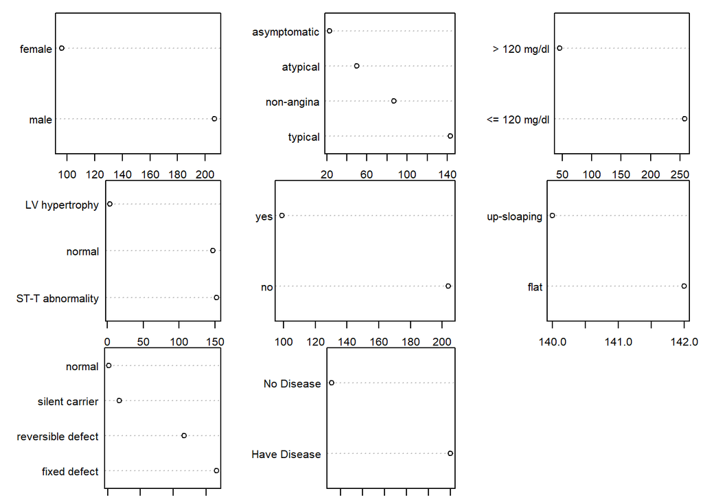

```r
# Histogram for all  Categorical Variables in The Heart Dataset each column individually.


heart_df_cat1 <- heart_df %>%
  select(Sex , Chest_Pain_Type, Fasting_Blood_Sugar ,
         Resting_ECG, Exercise_Induced_Angina ,
         Peak_Exercise_ST_Segment , Thalassemia ,
         Diagnosis_Heart_Disease)%>%
         mutate(Sex = recode_factor(Sex, `0` = "female", `1` = "male" ),
         Chest_Pain_Type = recode_factor(Chest_Pain_Type,`0` = "typical",
                                                         `1` = "atypical",
                                                         `2` = "non-angina",
                                                         `3`="asymptomatic"),
         Fasting_Blood_Sugar =
         recode_factor(Fasting_Blood_Sugar,`0`="<= 120 mg/dl",
                                           `1`="> 120 mg/dl"),
          Resting_ECG = recode_factor(Resting_ECG, `0` = "normal",
                                                   `1` = "ST-T abnormality",
                                                   `2` = "LV hypertrophy"),
          Exercise_Induced_Angina = recode_factor(Exercise_Induced_Angina,`0`="no",`1` = "yes"),
           Peak_Exercise_ST_Segment = recode_factor(Peak_Exercise_ST_Segment,`1`= "up-sloaping",
                                       `2` = "flat",
                                       `3` = "down-sloaping"),
          Thalassemia = recode_factor(Thalassemia,`0` = "normal",
                                                  `1` = "silent carrier",
                                                  `2` = "fixed defect",
                                                  `3` = "reversible defect"),

         Diagnosis_Heart_Disease = recode_factor(Diagnosis_Heart_Disease,
                                  `0` = "No Disease",`1` = "Have Disease") )






par(mar=c(1, 1, 1, 1))
hist.data.frame(heart_df_cat1)
```

And now visualize the numiric variables in the Heart Dataset (Age,Resting_Blood_Pressure,Cholesterol_serum, Maximum_Heart_Rate,ST_Depression_Exercise,Num_Major_Vessels_Flourosopy)

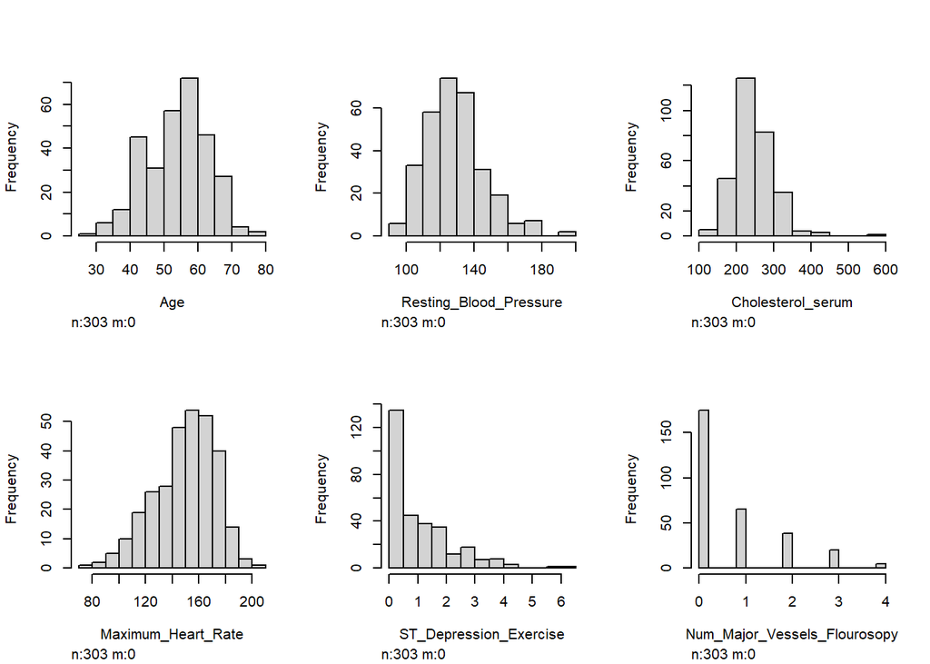

```r
# Histogram for all numeric Variables in The Heart Dataset each column individually.
heart_df_num <- heart_df %>% select(Age,Resting_Blood_Pressure,Cholesterol_serum,
        Maximum_Heart_Rate, ST_Depression_Exercise, Num_Major_Vessels_Flourosopy)

hist.data.frame(heart_df_num)
```

When visualizing the previous plots we can have an idea of the high rates of variables may cause a heart disease, may this can give us an idea of the relations between these variables.  
Highly correlated variables can lead to overly complicated models or wonky predictions. we will find the correlations between the variables after we moved in our analysis.

Lets visualize more in our variables.  
Let us compute each gender, and plot it.

```r
heart_df %>%
  drop_na() %>%
  group_by(Sex) %>%
  count() %>%
  ungroup()
```

```
## # A tibble: 2 x 2
##     Sex     n
##   <int> <int>
## 1     0    96
## 2     1   207
```

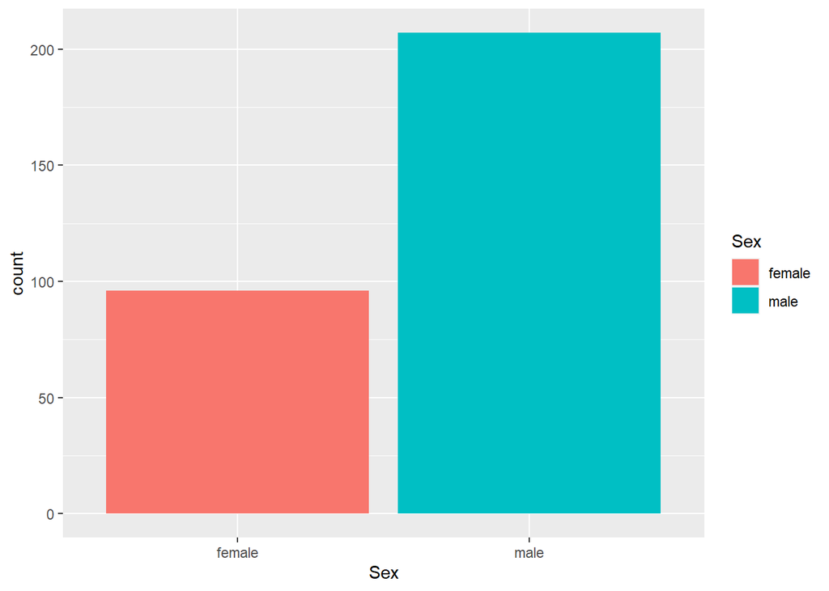

```r
heart_df_gender <- heart_df %>%
    select(Sex)%>%
    mutate(Sex = recode_factor(Sex, `0` = "female", `1` = "male" )
    )

ggplot(heart_df_gender) +
                   geom_bar(aes(x = Sex ,fill=Sex ) )
```

Now let us calculate how many individuals that could be Diagnosed to suffer from heart disease

```r
heart_df %>%
  drop_na() %>%
  group_by(Diagnosis_Heart_Disease) %>%
  count() %>%
  ungroup()
```

```
## # A tibble: 2 x 2
##   Diagnosis_Heart_Disease     n
##                     <int> <int>
## 1                       0   138
## 2                       1   165
```

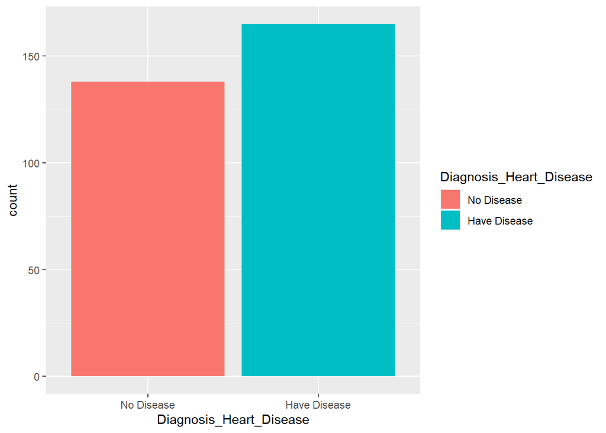

```r
heart_df_diseased <- heart_df %>%
    select(Diagnosis_Heart_Disease)%>%
    mutate(Diagnosis_Heart_Disease = recode_factor(Diagnosis_Heart_Disease, `0` = "No Disease", `1` = "Have Disease" )
    )

ggplot(heart_df_diseased) +
                   geom_bar(aes(x = Diagnosis_Heart_Disease ,fill=Diagnosis_Heart_Disease ) )
```

As we see the results the total count of having heart disease (1 = present of disease) is 165 which is higher than not having a heart disease (0 = absence) 138.

Now let us show Diagnosis Heart Disease by gender for all types of chest pain

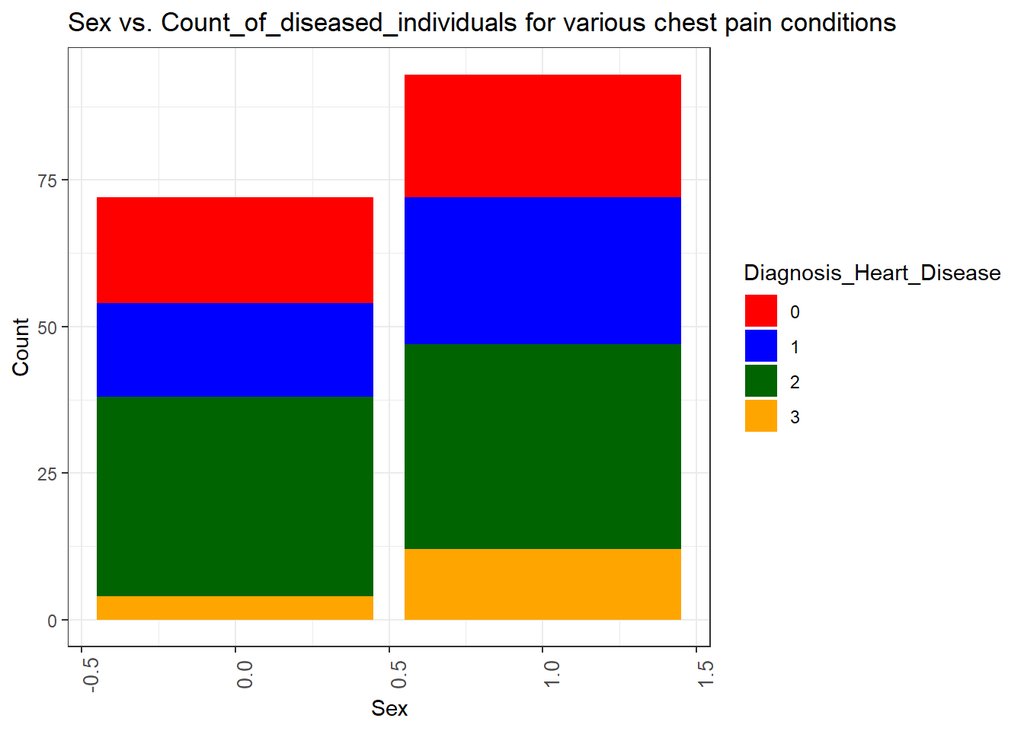

```r
heart_df %>% filter(Diagnosis_Heart_Disease == 1) %>% group_by(Sex, Chest_Pain_Type) %>% summarise(count = n()) %>%
  ggplot() + geom_bar(aes(Sex, count,   fill = as.factor(Chest_Pain_Type)),stat = "Identity") +
  theme_bw() +
  theme(axis.text.x = element_text(angle = 90, size = 10)) +
  ylab("Count") + xlab("Sex") + labs(fill = "Diagnosis_Heart_Disease") +
  ggtitle("Sex vs. Count_of_diseased_individuals for various chest pain conditions") +
  scale_fill_manual(values=c("red", "blue", "darkgreen", "orange"))
```

Individuals having Thalassemia may have a higher chance of having heart disease , if this is true lets make visualization on this to know.

Show levels of Thalassemia

```r
heart_df %>%
  drop_na() %>%
  group_by(Thalassemia) %>%
  count() %>%
  ungroup()
```

```
## # A tibble: 4 x 2
##   Thalassemia     n
##         <int> <int>
## 1           0     2
## 2           1    18
## 3           2   166
## 4           3   117
```

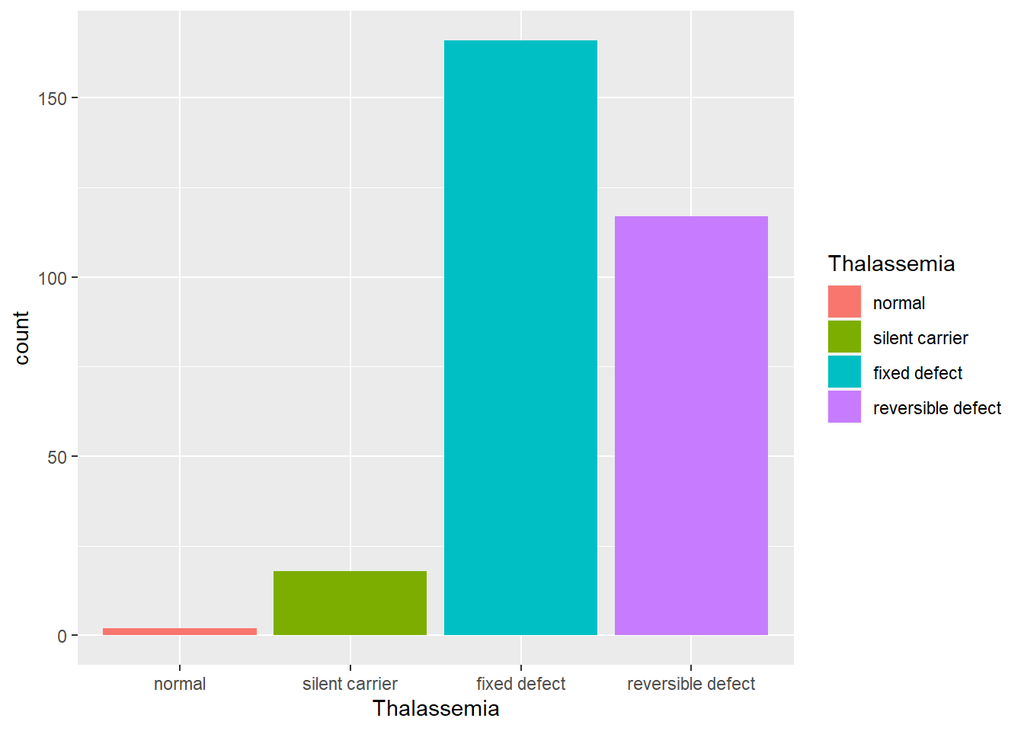

```r
heart_df_Thalassemia <- heart_df %>%
    select(Thalassemia)%>%
    mutate(Thalassemia =recode_factor(Thalassemia,`0` = "normal",
                                                  `1` = "silent carrier",
                                                  `2` = "fixed defect",
                                                  `3` = "reversible defect"))

ggplot(heart_df_Thalassemia) +
                   geom_bar(aes(x = Thalassemia ,fill=Thalassemia ) )
```

Let us show a diagram explains Chest pain type for diseased people with Age classifications

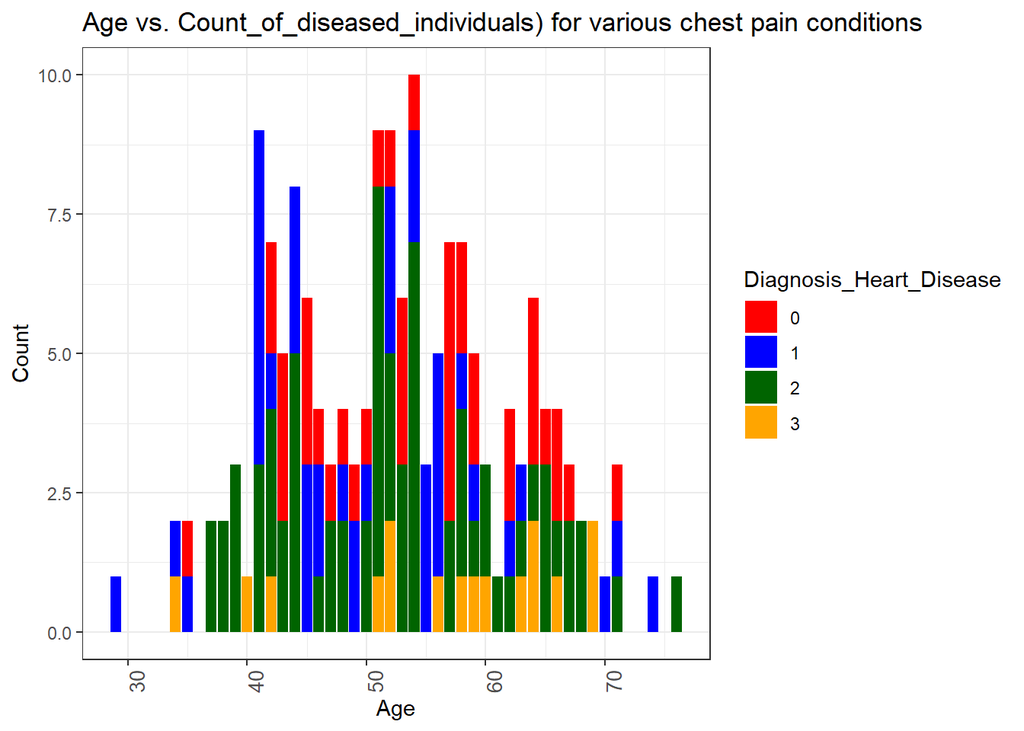

```r
heart_df %>% filter(Diagnosis_Heart_Disease == 1) %>% group_by(Age, Chest_Pain_Type) %>% summarise(count = n()) %>%
  ggplot() + geom_bar(aes(Age, count,   fill = as.factor(Chest_Pain_Type)),stat = "Identity") +
  theme_bw() +
  theme(axis.text.x = element_text(angle = 90, size = 10)) +
  ylab("Count") + xlab("Age") + labs(fill = "Diagnosis_Heart_Disease") +
  ggtitle("Age vs. Count_of_diseased_individuals) for various chest pain conditions") +
  scale_fill_manual(values=c("red", "blue", "darkgreen", "orange"))
```

Methods of Machine Learning

Variables that are highly correlated could give us correct predictions or incorrect predictions,we are going to start with finding the correlated variables so we can have a high prediction.

Let us use function from GGally library which is ggcorr() to make a correlation matrix of the numeric variables, we have two methods to apply, the first one is Pearson which is not that ideal method if the data has too much outliers, the second method is Kendall, which is more suitable for our data.  
Let us check both of them.

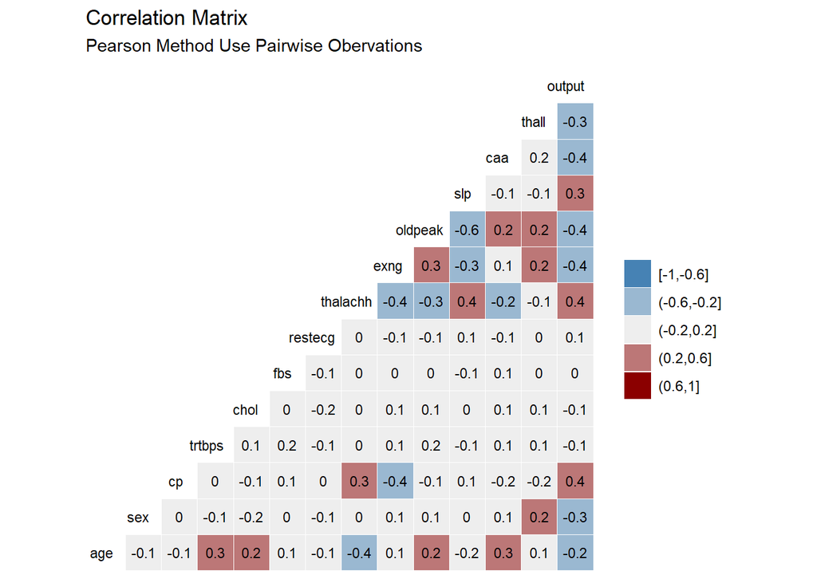

```r
# to use the short names of the data frame, we use the data frame that we initiate previously with shortcut names.

#Correlation matrix using Pearson method, default method is Pearson
heart_df_oldnames %>% ggcorr(high       = "darkred",
                             low        = "steelblue",
                             label      = TRUE,
                             hjust      = .75,
                             size       = 3,
                             label_size = 3,
                             nbreaks    = 5
                                              ) +
  labs(title = "Correlation Matrix",
  subtitle = "Pearson Method Use Pairwise Obervations")
```

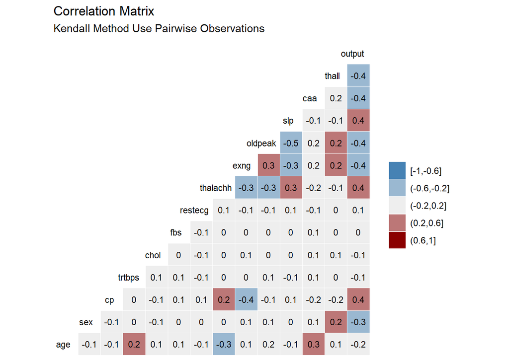

```r
#Correlation matrix using Kendall method
heart_df_oldnames %>% ggcorr(method     = c("pairwise", "kendall"),
                             high       = "darkred",
                             low        = "steelblue",
                             label      = TRUE,
                             hjust      = .75,
                             size       = 3,
                             label_size = 3,
                             nbreaks    = 5
                                   ) +
  labs(title = "Correlation Matrix",
  subtitle = "Kendall Method Use Pairwise Observations")
```

There are a slight differences between the Pearson and Kendall results, the variables are not highly correlated.

Machine Learning Basics

We will apply machine learning methods to compute the accuracy of our prediction using these machine learning methods:  
Logistic Regression  
Regression and Decision Trees  
Quadrant Discriminant Analysis (QDA)  
Linear Discriminamt Analaysis (LDA)  
K-Nearest Neighbours Classifier (KNN)  
Support Vector Machine (SVM)  
Random Forest (RF)  
Gradient Boosting Machine (GBM)

Before we start with the algorithms, we will split our dataset to training and test set, to compare our results.

Training and Test sets, and overall accuracy

```r
#create Data Partition
#set seed for reproducible results
set.seed(1)

test_index <- createDataPartition(y = heart_df$Diagnosis_Heart_Disease, times = 1, p = 0.1, list = FALSE)
train_heart_df <- heart_df[-test_index, ]
test_heart_df <- heart_df[test_index, ]
```

After we partition our dataset lets check the dimension of each training and test set

```r
#dimension of the training data set

dim(train_heart_df)
```

```
## [1] 272  14
```

```r
#dimension of the test data set

dim(test_heart_df)
```

```
## [1] 31 14
```

Applying Methods of Machine Learning

It is convenient to start working with Logistic regression model since it is relatively easy to implement and yields results that have intuitive meaning.  
Logistic Regression Logistic regression is a statistical model that in its basic form uses a logistic function to model a binary dependent variable, Mathematically, a binary logistic model has a dependent variable with two possible values, such as pass/fail which is represented by an indicator variable, where the two values are labeled “0” and “1”.

```r
#Logistic Regression model
set.seed(1)

    log_regr_hd_model = glm(Diagnosis_Heart_Disease~., data=train_heart_df, family='binomial')

 summary(log_regr_hd_model)
```

```
##
## Call:
## glm(formula = Diagnosis_Heart_Disease ~ ., family = "binomial",
##     data = train_heart_df)
##
## Deviance Residuals:
##     Min       1Q   Median       3Q      Max
## -2.5633  -0.3960   0.1469   0.5876   2.5025
##
## Coefficients:
##                               Estimate Std. Error z value Pr(>|z|)
## (Intercept)                   3.973030   2.775290   1.432  0.15227
## Age                          -0.009467   0.024845  -0.381  0.70317
## Sex                          -1.577591   0.482908  -3.267  0.00109 **
## Chest_Pain_Type               0.804998   0.195659   4.114 3.88e-05 ***
## Resting_Blood_Pressure       -0.020459   0.011019  -1.857  0.06334 .
## Cholesterol_serum            -0.004707   0.003816  -1.233  0.21745
## Fasting_Blood_Sugar           0.222651   0.547886   0.406  0.68446
## Resting_ECG                   0.588453   0.361832   1.626  0.10388
## Maximum_Heart_Rate            0.021039   0.011166   1.884  0.05952 .
## Exercise_Induced_Angina      -1.108258   0.441805  -2.508  0.01213 *
## ST_Depression_Exercise       -0.591779   0.224294  -2.638  0.00833 **
## Peak_Exercise_ST_Segment      0.329832   0.384015   0.859  0.39039
## Num_Major_Vessels_Flourosopy -0.811153   0.205034  -3.956 7.62e-05 ***
## Thalassemia                  -0.703026   0.303807  -2.314  0.02066 *
## ---
## Signif. codes:  0 '***' 0.001 '**' 0.01 '*' 0.05 '.' 0.1 ' ' 1
##
## (Dispersion parameter for binomial family taken to be 1)
##
##     Null deviance: 375.88  on 271  degrees of freedom
## Residual deviance: 194.68  on 258  degrees of freedom
## AIC: 222.68
##
## Number of Fisher Scoring iterations: 6
```

Some variables are not significant. So let us check the Multi collinearity

```r
cor(train_heart_df)
```

```
##                                      Age         Sex Chest_Pain_Type
## Age                           1.00000000 -0.05870629     -0.06804040
## Sex                          -0.05870629  1.00000000     -0.04377826
## Chest_Pain_Type              -0.06804040 -0.04377826      1.00000000
## Resting_Blood_Pressure        0.28396173 -0.04375402      0.04203868
## Cholesterol_serum             0.20658040 -0.18134287     -0.06816631
## Fasting_Blood_Sugar           0.13143747  0.03045931      0.11803110
## Resting_ECG                  -0.13568375 -0.05752715      0.04857083
## Maximum_Heart_Rate           -0.39893973 -0.07514824      0.28072394
## Exercise_Induced_Angina       0.07380707  0.13371352     -0.41976875
## ST_Depression_Exercise        0.21859497  0.08746082     -0.15593697
## Peak_Exercise_ST_Segment     -0.19643157 -0.01481500      0.09172991
## Num_Major_Vessels_Flourosopy  0.28647423  0.10479789     -0.19415542
## Thalassemia                   0.08699454  0.19848152     -0.14624579
## Diagnosis_Heart_Disease      -0.24448346 -0.26153760      0.42576193
##                              Resting_Blood_Pressure Cholesterol_serum
## Age                                      0.28396173       0.206580398
## Sex                                     -0.04375402      -0.181342874
## Chest_Pain_Type                          0.04203868      -0.068166309
## Resting_Blood_Pressure                   1.00000000       0.100325028
## Cholesterol_serum                        0.10032503       1.000000000
## Fasting_Blood_Sugar                      0.20139639       0.004711190
## Resting_ECG                             -0.14443945      -0.148402911
## Maximum_Heart_Rate                      -0.05858395       0.015706402
## Exercise_Induced_Angina                  0.06103037       0.065650539
## ST_Depression_Exercise                   0.22734189       0.058825454
## Peak_Exercise_ST_Segment                -0.17508757      -0.009920242
## Num_Major_Vessels_Flourosopy             0.10094911       0.089192150
## Thalassemia                              0.09198073       0.116601563
## Diagnosis_Heart_Disease                 -0.16998535      -0.096735010
##                              Fasting_Blood_Sugar Resting_ECG Maximum_Heart_Rate
## Age                                   0.13143747 -0.13568375        -0.39893973
## Sex                                   0.03045931 -0.05752715        -0.07514824
## Chest_Pain_Type                       0.11803110  0.04857083         0.28072394
## Resting_Blood_Pressure                0.20139639 -0.14443945        -0.05858395
## Cholesterol_serum                     0.00471119 -0.14840291         0.01570640
## Fasting_Blood_Sugar                   1.00000000 -0.09923581        -0.02722403
## Resting_ECG                          -0.09923581  1.00000000         0.05454858
## Maximum_Heart_Rate                   -0.02722403  0.05454858         1.00000000
## Exercise_Induced_Angina               0.03470234 -0.07131224        -0.37732003
```

[output cut: 50 more lines]

```
##                              Diagnosis_Heart_Disease
## Age                                      -0.24448346
## Sex                                      -0.26153760
## Chest_Pain_Type                           0.42576193
## Resting_Blood_Pressure                   -0.16998535
## Cholesterol_serum                        -0.09673501
## Fasting_Blood_Sugar                      -0.01764299
## Resting_ECG                               0.17248328
## Maximum_Heart_Rate                        0.40938532
## Exercise_Induced_Angina                  -0.44675167
## ST_Depression_Exercise                   -0.43356195
## Peak_Exercise_ST_Segment                  0.32155268
## Num_Major_Vessels_Flourosopy             -0.40327705
## Thalassemia                              -0.31905104
## Diagnosis_Heart_Disease                   1.00000000
```

Since it’s hard to find which variables are highly correlated. We will see only the variables with correlation > 0.7 or < -0.7

```r
abs(cor(train_heart_df))>0.7
```

```
##                                Age   Sex Chest_Pain_Type Resting_Blood_Pressure
## Age                           TRUE FALSE           FALSE                  FALSE
## Sex                          FALSE  TRUE           FALSE                  FALSE
## Chest_Pain_Type              FALSE FALSE            TRUE                  FALSE
## Resting_Blood_Pressure       FALSE FALSE           FALSE                   TRUE
## Cholesterol_serum            FALSE FALSE           FALSE                  FALSE
## Fasting_Blood_Sugar          FALSE FALSE           FALSE                  FALSE
## Resting_ECG                  FALSE FALSE           FALSE                  FALSE
## Maximum_Heart_Rate           FALSE FALSE           FALSE                  FALSE
## Exercise_Induced_Angina      FALSE FALSE           FALSE                  FALSE
## ST_Depression_Exercise       FALSE FALSE           FALSE                  FALSE
## Peak_Exercise_ST_Segment     FALSE FALSE           FALSE                  FALSE
## Num_Major_Vessels_Flourosopy FALSE FALSE           FALSE                  FALSE
## Thalassemia                  FALSE FALSE           FALSE                  FALSE
## Diagnosis_Heart_Disease      FALSE FALSE           FALSE                  FALSE
##                              Cholesterol_serum Fasting_Blood_Sugar Resting_ECG
## Age                                      FALSE               FALSE       FALSE
## Sex                                      FALSE               FALSE       FALSE
## Chest_Pain_Type                          FALSE               FALSE       FALSE
## Resting_Blood_Pressure                   FALSE               FALSE       FALSE
## Cholesterol_serum                         TRUE               FALSE       FALSE
## Fasting_Blood_Sugar                      FALSE                TRUE       FALSE
## Resting_ECG                              FALSE               FALSE        TRUE
## Maximum_Heart_Rate                       FALSE               FALSE       FALSE
## Exercise_Induced_Angina                  FALSE               FALSE       FALSE
## ST_Depression_Exercise                   FALSE               FALSE       FALSE
## Peak_Exercise_ST_Segment                 FALSE               FALSE       FALSE
## Num_Major_Vessels_Flourosopy             FALSE               FALSE       FALSE
## Thalassemia                              FALSE               FALSE       FALSE
## Diagnosis_Heart_Disease                  FALSE               FALSE       FALSE
##                              Maximum_Heart_Rate Exercise_Induced_Angina
## Age                                       FALSE                   FALSE
## Sex                                       FALSE                   FALSE
## Chest_Pain_Type                           FALSE                   FALSE
## Resting_Blood_Pressure                    FALSE                   FALSE
## Cholesterol_serum                         FALSE                   FALSE
## Fasting_Blood_Sugar                       FALSE                   FALSE
## Resting_ECG                               FALSE                   FALSE
## Maximum_Heart_Rate                         TRUE                   FALSE
## Exercise_Induced_Angina                   FALSE                    TRUE
```

[output cut: 35 more lines]

```
##                              Diagnosis_Heart_Disease
## Age                                            FALSE
## Sex                                            FALSE
## Chest_Pain_Type                                FALSE
## Resting_Blood_Pressure                         FALSE
## Cholesterol_serum                              FALSE
## Fasting_Blood_Sugar                            FALSE
## Resting_ECG                                    FALSE
## Maximum_Heart_Rate                             FALSE
## Exercise_Induced_Angina                        FALSE
## ST_Depression_Exercise                         FALSE
## Peak_Exercise_ST_Segment                       FALSE
## Num_Major_Vessels_Flourosopy                   FALSE
## Thalassemia                                    FALSE
## Diagnosis_Heart_Disease                         TRUE
```

```r
m_cor = melt(abs(cor(train_heart_df))>0.7)
head(m_cor)
```

```
##                     Var1 Var2 value
## 1                    Age  Age  TRUE
## 2                    Sex  Age FALSE
## 3        Chest_Pain_Type  Age FALSE
## 4 Resting_Blood_Pressure  Age FALSE
## 5      Cholesterol_serum  Age FALSE
## 6    Fasting_Blood_Sugar  Age FALSE
```

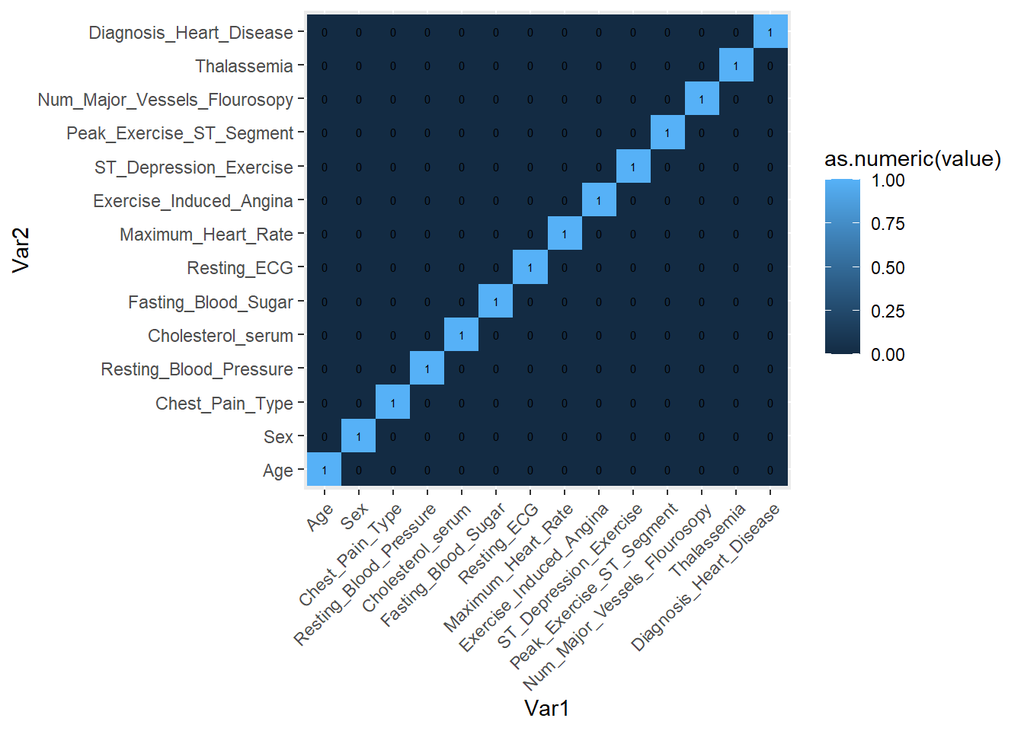

```r
ggplot(m_cor, aes(x = Var1, y=Var2, fill=as.numeric(value))) + geom_tile() +
geom_text(aes(Var1, Var2, label=as.numeric(value)),color='black',size=2)+
scale_color_gradient(low='blue',high='red') +
theme(axis.text.x = element_text(angle=45, vjust=1, hjust=1))
```

The heat map show’s that there are no highly correlated variables.  
So as there is no multi collinearity we will removing Variables based on Significance Level.

```r
    log_regr_hd_model2 = glm(Diagnosis_Heart_Disease~
                             Age+ Sex+
                             Chest_Pain_Type+
                             Resting_Blood_Pressure +
                             Cholesterol_serum +
                             Fasting_Blood_Sugar +
                             Resting_ECG  +
                             Maximum_Heart_Rate  +
                             Exercise_Induced_Angina  +
                             ST_Depression_Exercise  +
                             Peak_Exercise_ST_Segment +
                             Num_Major_Vessels_Flourosopy+
                             Thalassemia  ,
                             data=train_heart_df, family='binomial')

 summary(log_regr_hd_model2)
```

```
##
## Call:
## glm(formula = Diagnosis_Heart_Disease ~ Age + Sex + Chest_Pain_Type +
##     Resting_Blood_Pressure + Cholesterol_serum + Fasting_Blood_Sugar +
##     Resting_ECG + Maximum_Heart_Rate + Exercise_Induced_Angina +
##     ST_Depression_Exercise + Peak_Exercise_ST_Segment + Num_Major_Vessels_Flourosopy +
##     Thalassemia, family = "binomial", data = train_heart_df)
##
## Deviance Residuals:
##     Min       1Q   Median       3Q      Max
## -2.5633  -0.3960   0.1469   0.5876   2.5025
##
## Coefficients:
##                               Estimate Std. Error z value Pr(>|z|)
## (Intercept)                   3.973030   2.775290   1.432  0.15227
## Age                          -0.009467   0.024845  -0.381  0.70317
## Sex                          -1.577591   0.482908  -3.267  0.00109 **
## Chest_Pain_Type               0.804998   0.195659   4.114 3.88e-05 ***
## Resting_Blood_Pressure       -0.020459   0.011019  -1.857  0.06334 .
## Cholesterol_serum            -0.004707   0.003816  -1.233  0.21745
## Fasting_Blood_Sugar           0.222651   0.547886   0.406  0.68446
## Resting_ECG                   0.588453   0.361832   1.626  0.10388
## Maximum_Heart_Rate            0.021039   0.011166   1.884  0.05952 .
## Exercise_Induced_Angina      -1.108258   0.441805  -2.508  0.01213 *
## ST_Depression_Exercise       -0.591779   0.224294  -2.638  0.00833 **
## Peak_Exercise_ST_Segment      0.329832   0.384015   0.859  0.39039
## Num_Major_Vessels_Flourosopy -0.811153   0.205034  -3.956 7.62e-05 ***
## Thalassemia                  -0.703026   0.303807  -2.314  0.02066 *
## ---
## Signif. codes:  0 '***' 0.001 '**' 0.01 '*' 0.05 '.' 0.1 ' ' 1
##
## (Dispersion parameter for binomial family taken to be 1)
##
##     Null deviance: 375.88  on 271  degrees of freedom
## Residual deviance: 194.68  on 258  degrees of freedom
## AIC: 222.68
##
## Number of Fisher Scoring iterations: 6
```

```r
    log_regr_hd_model2 = glm(Diagnosis_Heart_Disease~
                             Age+ Sex+
                             Chest_Pain_Type+
                             Resting_Blood_Pressure +
                             Cholesterol_serum +
                             Resting_ECG  +
                             Maximum_Heart_Rate  +
                             Exercise_Induced_Angina  +
                             ST_Depression_Exercise  +
                             Peak_Exercise_ST_Segment +
                             Num_Major_Vessels_Flourosopy+
                             Thalassemia  ,
                             data=train_heart_df, family='binomial')

 summary(log_regr_hd_model2)
```

```
##
## Call:
## glm(formula = Diagnosis_Heart_Disease ~ Age + Sex + Chest_Pain_Type +
##     Resting_Blood_Pressure + Cholesterol_serum + Resting_ECG +
##     Maximum_Heart_Rate + Exercise_Induced_Angina + ST_Depression_Exercise +
##     Peak_Exercise_ST_Segment + Num_Major_Vessels_Flourosopy +
##     Thalassemia, family = "binomial", data = train_heart_df)
##
## Deviance Residuals:
##     Min       1Q   Median       3Q      Max
## -2.5739  -0.3880   0.1457   0.5919   2.4911
##
## Coefficients:
##                               Estimate Std. Error z value Pr(>|z|)
## (Intercept)                   3.918568   2.775170   1.412  0.15795
## Age                          -0.008547   0.024805  -0.345  0.73042
## Sex                          -1.565462   0.482564  -3.244  0.00118 **
## Chest_Pain_Type               0.821745   0.192280   4.274 1.92e-05 ***
## Resting_Blood_Pressure       -0.020022   0.010969  -1.825  0.06796 .
## Cholesterol_serum            -0.004677   0.003807  -1.228  0.21929
## Resting_ECG                   0.582427   0.361349   1.612  0.10700
## Maximum_Heart_Rate            0.021138   0.011169   1.893  0.05841 .
## Exercise_Induced_Angina      -1.086876   0.439192  -2.475  0.01333 *
## ST_Depression_Exercise       -0.599451   0.223745  -2.679  0.00738 **
## Peak_Exercise_ST_Segment      0.320378   0.381555   0.840  0.40110
## Num_Major_Vessels_Flourosopy -0.800503   0.203310  -3.937 8.24e-05 ***
## Thalassemia                  -0.728334   0.296388  -2.457  0.01400 *
## ---
## Signif. codes:  0 '***' 0.001 '**' 0.01 '*' 0.05 '.' 0.1 ' ' 1
##
## (Dispersion parameter for binomial family taken to be 1)
##
##     Null deviance: 375.88  on 271  degrees of freedom
## Residual deviance: 194.84  on 259  degrees of freedom
## AIC: 220.84
##
## Number of Fisher Scoring iterations: 6
```